# Geog533 Final Project

Michael Kezner

December 1, 2017

## Introduction

For this project, I will be analyzing tweets from Fort Collins, Colorado. In addition, I will be comparing them to tweets from Denver, another city in Colorado, and Sioux Falls, South Dakota another city in the United States with a similar population size. To do this, I will be generating a word cloud for each city in order to see what people are talking about and if they are the same or not. I will also be performing a sentiment analysis to see whether people have positive or negative things to say about these cities. Finally, I will map the location of origin of the tweets to see whether people are tweeting from these cities from within their boundaries or from other cities.

## Setting Up

### Installing and Loading R Packages

```r
if (!require(twitteR)) {install.packages("twitteR")}
if (!require(ROAuth)) {install.packages("ROAuth")}
if (!require(tm)) {install.packages("tm")}
if (!require(wordcloud)) {install.packages("wordcloud")}
if (!require(plyr)) {install.packages("plyr")}
if (!require(dplyr)) {install.packages("dplyr")}
if (!require(stringr)) {install.packages("stringr")}
if (!require(ggplot2)) {install.packages("ggplot2")}
if(!require(leaflet)) {install.packages("leaflet")}
library(twitteR)
library(ROAuth)
library(tm)
library(wordcloud)
library(plyr)
library(dplyr)
library(stringr)
library(ggplot2)
library(leaflet)
```

### Authentication

```r
my.consumer.key = "ZVZAiKWzWQ7hycdDJ84mOya5V"
my.consumer.secret = "6ZOAHASDYiQJDBwLgI8NvLGTsUM2UXeawHvyCSwEDssQ2a6f5R"
my.access.token = "719285386325979136-sEoMws7TTFANiULq0rtW66rSQFIpTO4"
my.access.token.secret = "npkmEAtozfxLyXikAbRQgu0DNl07BjjGsHWNZhydoi63i"
my_oauth <- setup_twitter_oauth(consumer_key = my.consumer.key, consumer_secret = my.consumer.secret, access_token = my.access.token, access_secret = my.access.token.secret)
```

```
[1] "Using direct authentication"
```

```r
save(my_oauth, file = "my_oauth.Rdata")
```

## Extracting Text

Here I will extract 1350 tweets about each city from the week of November 27, 2017 and convert them to a data frame

#### Fort Collins

```r
fc <- searchTwitter(searchString = '#fortcollins OR Fort Collins', n = 1350, since = '2017-11-27', until = '2017-12-01')
fcdf <- twListToDF(fc)
write.csv(fcdf, "fcdf.csv")
```

#### Denver

```r
den <- searchTwitter(searchString = '#denver OR Denver', n = 1350, since = '2017-11-27', until = '2017-12-01')
denverdf <- twListToDF(den)
write.csv(denverdf, "denverdf.csv")
```

#### Sioux Falls

```r
sf <- searchTwitter(searchString = '#siouxfalls OR Sioux Falls', n = 1350, since = '2017-11-27', until = '2017-12-01')
siouxdf <- twListToDF(sf)
write.csv(siouxdf, "siouxdf1.csv")
```

## Generating Word Clouds

In this section, I will generate word clouds for the words that appear the most from each city and then create a table showing the 10 most frequent terms from the cities

### Authentication

```r
my.consumer.key = "ZVZAiKWzWQ7hycdDJ84mOya5V"
my.consumer.secret = "6ZOAHASDYiQJDBwLgI8NvLGTsUM2UXeawHvyCSwEDssQ2a6f5R"
my.access.token = "719285386325979136-sEoMws7TTFANiULq0rtW66rSQFIpTO4"
my.access.token.secret = "npkmEAtozfxLyXikAbRQgu0DNl07BjjGsHWNZhydoi63i"
my_oauth <- setup_twitter_oauth(consumer_key = my.consumer.key, consumer_secret = my.consumer.secret, access_token = my.access.token, access_secret = my.access.token.secret)
```

```
[1] "Using direct authentication"
```

```r
save(my_oauth, file = "my_oauth.Rdata")
```

### Getting the Text

```r
fc.text <- sapply(fc, function(x) x$getText())
denver.text <- sapply(den, function(x) x$getText())
sioux.text <- sapply(sf, function(x) x$getText())
```

### Cleaning Up the Text

#### Fort Collins

```r
# Replace blank space (“rt”)
fc.text <- gsub("rt", "", fc.text)
# Replace @UserName
fc.text <- gsub("@\\w+", "", fc.text)
# Remove punctuation
fc.text <- gsub("[[:punct:]]", "", fc.text)
# Remove links
fc.text <- gsub("http\\w+", "", fc.text)
# Remove tabs
fc.text <- gsub("[ |\t]{2,}", "", fc.text)
# Remove blank spaces at the beginning
fc.text <- gsub("^ ", "", fc.text)
# Remove blank spaces at the end
fc.text <- gsub(" $", "", fc.text)
# Remove numbers
fc.text <- gsub("[[:digit:]]+", " ", fc.text)
# Remove non graphical characters
fc.text <- gsub("[^[:graph:]]", " ", fc.text)
# Convert all text to lower case
fc.text <- tolower(fc.text)
```

#### Denver

```r
denver.text <- gsub("rt", "", denver.text)
denver.text <- gsub("@\\w+", "", denver.text)
denver.text <- gsub("[[:punct:]]", "", denver.text)
denver.text <- gsub("http\\w+", "", denver.text)
denver.text <- gsub("[ |\t]{2,}", "", denver.text)
denver.text <- gsub("^ ", "", denver.text)
denver.text <- gsub(" $", "", denver.text)
denver.text <- gsub("[[:digit:]]+", " ", denver.text)
denver.text <- gsub("[^[:graph:]]", " ", denver.text)
denver.text <- tolower(denver.text)
```

#### Sioux Falls

```r
sioux.text <- gsub("rt", "", sioux.text)
sioux.text <- gsub("@\\w+", "", sioux.text)
sioux.text <- gsub("[[:punct:]]", "", sioux.text)
sioux.text <- gsub("http\\w+", "", sioux.text)
sioux.text <- gsub("[ |\t]{2,}", "", sioux.text)
sioux.text <- gsub("^ ", "", sioux.text)
sioux.text <- gsub(" $", "", sioux.text)
sioux.text <- gsub("[[:digit:]]+", " ", sioux.text)
sioux.text <- gsub("[^[:graph:]]", " ", sioux.text)
sioux.text <- tolower(sioux.text)
```

### Creating a Corpus

#### Fort Collins

```r
# Create a corpus
fc.text.corpus <- Corpus(VectorSource(fc.text))
# Remove stop words
fc.text.corpus <- tm_map(fc.text.corpus, function(x) removeWords(x,stopwords()))
# Remove specific words
fc.text.corpus <- tm_map(fc.text.corpus, removeWords, c("via", "rtfo", "amp", "focollins", "time", "day", "nov", "rtcolorado", "will", "new"))
```

#### Denver

```r
denver.text.corpus <- Corpus(VectorSource(denver.text))
denver.text.corpus <- tm_map(denver.text.corpus, function(x) removeWords(x,stopwords()))
denver.text.corpus <- tm_map(denver.text.corpus, removeWords, c("amp", "will", "get", "coming", "rtnew"))
```

#### Sioux Falls

```r
sioux.text.corpus <- Corpus(VectorSource(sioux.text))
sioux.text.corpus <- tm_map(sioux.text.corpus, function(x) removeWords(x,stopwords()))
sioux.text.corpus <- tm_map(sioux.text.corpus, removeWords, c("time","find"))
```

### Word Clouds

#### Fort Collins

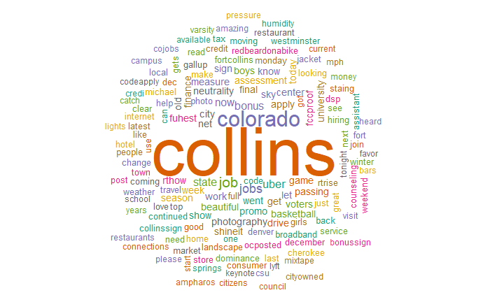

```r
wordcloud(fc.text.corpus,min.freq = 5, scale=c(6,0.7),colors=brewer.pal(8, "Dark2"),  random.color= TRUE, random.order = FALSE, max.words = 150)
```

#### Denver

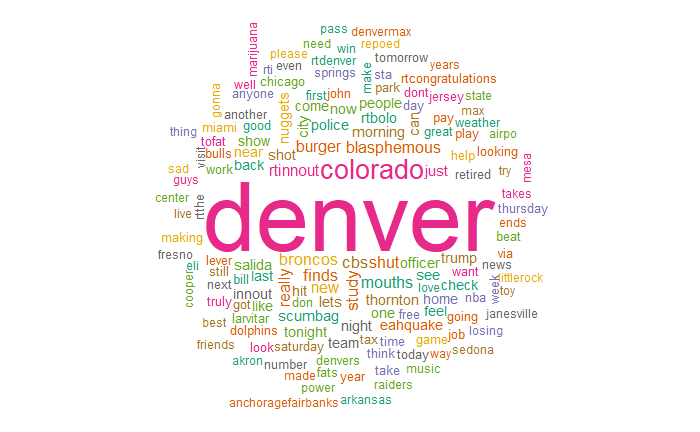

```r
wordcloud(denver.text.corpus, min.freq = 5, scale=c(6,0.7),colors=brewer.pal(8, "Dark2"),  random.color= TRUE, random.order = FALSE, max.words = 150)
```

#### Sioux Falls

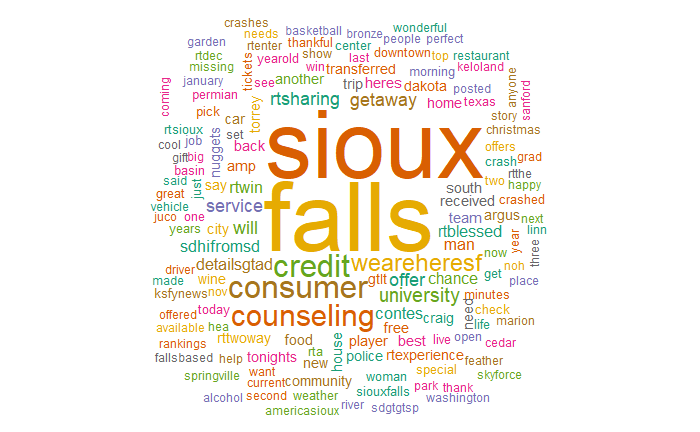

```r
wordcloud(sioux.text.corpus,min.freq = 5, scale=c(6,0.7),colors=brewer.pal(8, "Dark2"),  random.color= TRUE, random.order = FALSE, max.words = 150)
```

### Word Frequencies

#### Fort Collins

```r
fctdm <- as.matrix(TermDocumentMatrix(fc.text.corpus))
fcfreq <- data.frame(Words = rownames(fctdm), Frequency = rowSums(fctdm), row.names = NULL)
fctable <- fcfreq[order(fcfreq$Frequency, decreasing = TRUE),]
head(fctable, 10)
```

|  | Words | Frequency |
| --- | --- | --- |
| 2 | collins | 944 |
| 7 | colorado | 228 |
| 395 | job | 104 |
| 140 | jobs | 71 |
| 1100 | uber | 59 |
| 24 | state | 58 |
| 2129 | bonus | 53 |
| 195 | now | 52 |
| 708 | work | 46 |
| 200 | city | 42 |

#### Denver

```r
denvertdm <- as.matrix(TermDocumentMatrix(denver.text.corpus))
denverfreq <- data.frame(Words = rownames(denvertdm), Frequency = rowSums(denvertdm), row.names = NULL)
denvertable <- denverfreq[order(denverfreq$Frequency, decreasing = TRUE),]
head(denvertable, 10)
```

|  | Words | Frequency |
| --- | --- | --- |
| 5 | denver | 742 |
| 78 | colorado | 139 |
| 157 | broncos | 54 |
| 122 | cbs | 49 |
| 123 | finds | 49 |
| 126 | study | 49 |
| 121 | blasphemous | 47 |
| 124 | mouths | 47 |
| 125 | shut | 47 |
| 148 | rtinnout | 43 |

#### Sioux Falls

```r
siouxtdm <- as.matrix(TermDocumentMatrix(sioux.text.corpus))
siouxfreq <- data.frame(Words = rownames(siouxtdm), Frequency = rowSums(siouxtdm), row.names = NULL)
siouxtable <- siouxfreq[order(siouxfreq$Frequency, decreasing = TRUE),]
head(siouxtable, 10)
```

|  | Words | Frequency |
| --- | --- | --- |
| 24 | falls | 984 |
| 30 | sioux | 966 |
| 77 | credit | 243 |
| 75 | consumer | 240 |
| 76 | counseling | 218 |
| 49 | weareheresf | 153 |
| 89 | university | 104 |
| 185 | getaway | 84 |
| 86 | offer | 82 |
| 165 | service | 82 |

## Sentiment Analysis

In this section, I will analyze sentiments for each city. Text files containing positive and negative words are used.

### Authentication

```r
my.consumer.key = "ZVZAiKWzWQ7hycdDJ84mOya5V"
my.consumer.secret = "6ZOAHASDYiQJDBwLgI8NvLGTsUM2UXeawHvyCSwEDssQ2a6f5R"
my.access.token = "719285386325979136-sEoMws7TTFANiULq0rtW66rSQFIpTO4"
my.access.token.secret = "npkmEAtozfxLyXikAbRQgu0DNl07BjjGsHWNZhydoi63i"
my_oauth <- setup_twitter_oauth(consumer_key = my.consumer.key, consumer_secret = my.consumer.secret, access_token = my.access.token, access_secret = my.access.token.secret)
```

```
[1] "Using direct authentication"
```

```r
save(my_oauth, file = "my_oauth.Rdata")
```

### Positive and Negative Words

```r
neg <- scan("negative-words.txt", what="character", comment.char=";")
```

```
Read 4783 items
```

```r
pos <- scan("positive-words.txt", what="character", comment.char=";")
```

```
Read 2006 items
```

### Function to Score Tweets

```r
score.sentiment <-  function(tweets, pos.words, neg.words)
{
scores <-  laply(tweets, function(tweet, pos.words, neg.words) {
tweet <-  gsub('https://','',tweet) # removes https://
tweet <-  gsub('http://','',tweet) # removes http://
tweet <- gsub('[^[:graph:]]', ' ',tweet) ## removes graphic characters  #like emoticons
tweet <-  gsub('[[:punct:]]', '', tweet) # removes punctuation
tweet <-  gsub('[[:cntrl:]]', '', tweet) # removes control characters
tweet <-  gsub('\\d+', '', tweet) # removes numbers
tweet <- str_replace_all(tweet,"[^[:graph:]]", " ")
tweet <-  tolower(tweet) # makes all letters lowercase
word.list <-  str_split(tweet, '\\s+') # splits the tweets by word in a list
words <-  unlist(word.list) # turns the list into vector
pos.matches <-  match(words, pos.words) ## returns matching values for words from list
neg.matches <-  match(words, neg.words)
pos.matches <-  !is.na(pos.matches) ## converts matching values to true of false
neg.matches <-  !is.na(neg.matches)

score <-  sum(pos.matches) - sum(neg.matches) # true and false are treated as 1 and 0 so they can be added

return(score)

}, pos.words, neg.words )

scores.df = data.frame(score=scores, text=tweets)

return(scores.df)

}
```

### Plotting Sentiment

#### Fort Collins

```r
fcanalysis <-  score.sentiment(fc.text, pos, neg)
table(fcanalysis$score)
```

```
 -4  -2  -1   0   1   2   3   4   5
  1   9  88 845 299  76  30   1   1
```

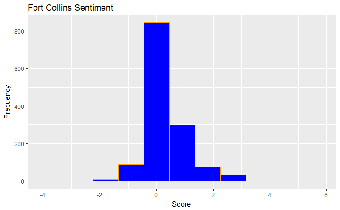

```r
qplot(fcanalysis$score,binwidth = 0.9, main = "Fort Collins Sentiment", xlab = "Score",ylab = "Frequency", fill = I("blue"), col = I("orange"))
```

```r
NA
```

#### Denver

```r
denveranalysis <-  score.sentiment(denver.text, pos, neg)
table(denveranalysis$score)
```

```
 -4  -3  -2  -1   0   1   2   3   4
  1   1  26 197 846 216  50  11   2
```

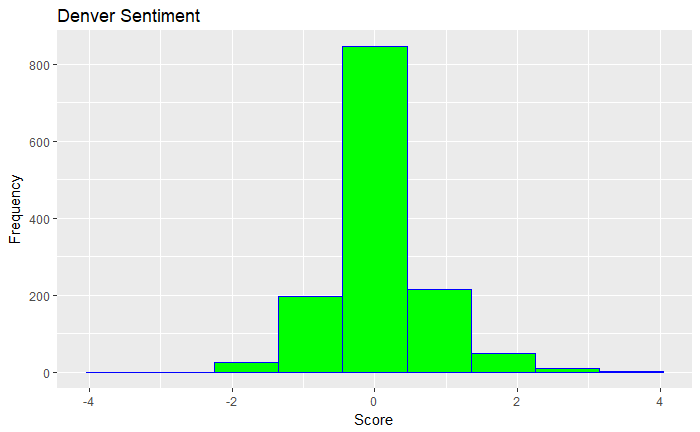

```r
qplot(denveranalysis$score,binwidth = 0.9, main = "Denver Sentiment", xlab = "Score",ylab = "Frequency", fill = I("green"), col = I("blue"))
```

#### Sioux Falls

```r
siouxanalysis <-  score.sentiment(sioux.text, pos, neg)
table(siouxanalysis$score)
```

```
 -5  -4  -3  -2  -1   0   1   2   3
  4   3  17  96 638 423 159   9   1
```

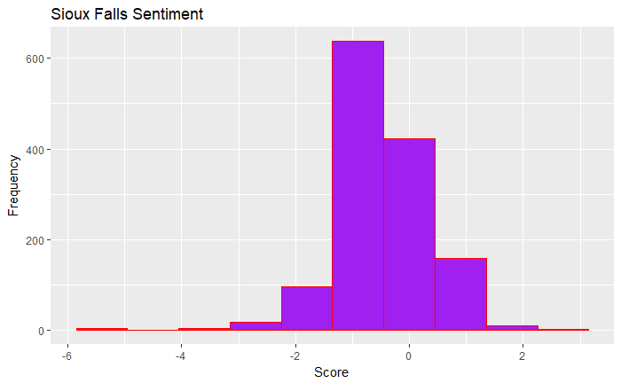

```r
qplot(siouxanalysis$score,binwidth = 0.9, main = "Sioux Falls Sentiment", xlab = "Score",ylab = "Frequency", fill = I("purple"), col = I("red"))
```

## Mapping the Tweets

In this section, I will map the locations of origin of the tweets that had coordinates attached to them. From this, I can see whether people are only talking about each city from inside them or if other people are also talking about them.

#### Fort Collins

```r
collins <- read.csv("fcdf.csv")
fcleaf <- leaflet(width = "100%") %>%
  addTiles() %>%
  addProviderTiles(provider = "Esri.WorldStreetMap",group = "World StreetMap") %>%
  addProviderTiles(provider = "Esri.WorldImagery",group = "World Imagery") %>%
  addLayersControl(
    baseGroups = c("OSM (default)","World StreetMap", "World Imagery"),
    options = layersControlOptions(collapsed = FALSE)) %>%
  addMarkers(label = collins$text, lng = collins$longitude, lat=collins$latitude, clusterOptions = markerClusterOptions())
```

```
Data contains 1288 rows with either missing or invalid lat/lon values and will be ignored
```

```r
fcleaf
```

[interactive chart not shown]

#### Denver

```r
denver <- read.csv("denverdf.csv")
denverleaf <- leaflet(width = "100%") %>%
  addTiles() %>%
  addProviderTiles(provider = "Esri.WorldStreetMap",group = "World StreetMap") %>%
  addProviderTiles(provider = "Esri.WorldImagery",group = "World Imagery") %>%
  addLayersControl(
    baseGroups = c("OSM (default)","World StreetMap", "World Imagery"),
    options = layersControlOptions(collapsed = FALSE)) %>%
  addMarkers(label = denver$text, lng = denver$longitude, lat=denver$latitude, clusterOptions = markerClusterOptions())
```

```
Data contains 1318 rows with either missing or invalid lat/lon values and will be ignored
```

```r
denverleaf
```

[interactive chart not shown]

#### Sioux Falls

```r
falls <- read.csv("siouxdf.csv")
fallsleaf <- leaflet(width = "100%") %>%
  addTiles() %>%
  addProviderTiles(provider = "Esri.WorldStreetMap",group = "World StreetMap") %>%
  addProviderTiles(provider = "Esri.WorldImagery",group = "World Imagery") %>%
  addLayersControl(
    baseGroups = c("OSM (default)","World StreetMap", "World Imagery"),
    options = layersControlOptions(collapsed = FALSE)) %>%
  addMarkers(label = falls$text, lng = falls$longitude, lat=falls$latitude, clusterOptions = markerClusterOptions())
fallsleaf
```

[interactive chart not shown]